# B12 · Where does the new task enter?

**PROVIDED:** visible fixed-kernel model, source archives and independent oracle. **TODO:** three live operations. **CHECK:** numerical and intervention feedback. **EXIT:** written defense.

Tier C synthetic mechanism isolation;36 conditions,432 predictions. No fitting or paid execution. This is not OpenRFM or Kumo inference. Paper targets and complete Griffin source are in the appendix.

```python
# @colab-bootstrap — standalone NumPy lab; no repository imports.
import importlib.util,subprocess,sys
if importlib.util.find_spec('numpy') is None:subprocess.check_call([sys.executable,'-m','pip','install','numpy'])
import numpy as np
import copy,hashlib,itertools,json,math,tempfile,base64,io,zipfile
from pathlib import Path
workspace=Path(tempfile.mkdtemp(prefix='b12-lab-'))
print('NumPy:',np.__version__,'; source and evidence workspace:',workspace)
```

```
NumPy: 2.5.0 ; source and evidence workspace: /tmp/b12-lab-nd0gwc4z
```

B11 compared models trained for a particular task. It left a practical question open: must a new prediction task require another training run? Here you will follow **how labeled examples change a prediction**. Your tangible win is a defensible adaptation matrix and a test that distinguishes a missing information path from an unhelpful one.

**Route through the lesson.** Recall the terms, trace three architectures, calculate one prediction, then run the corruption experiment. The source appendix is for auditing the reproduction boundary.

**Predict before continuing:** which labels can affect this query, and where do they enter?

A **query** is the example to predict. Here its identity is `(entity, cutoff)`, because the same entity at a later time has different available evidence. A **support example** is an example with an observed label supplied as context. A **label** is the answer to a prediction task. A **parameter** is a stored numerical weight learned during training. An **activation** is an intermediate value recomputed for the current input.

**Pretraining** learns reusable parameters across source data or tasks. **Fine-tuning** updates parameters for a downstream task. **In-context learning**, abbreviated ICL, changes predictions by supplying examples at inference; the stored parameters can remain fixed. A **checkpoint** saves those parameters. Frozen weights do not imply fixed predictions.

> **In plain terms.** Learning a new rule by changing your notes resembles fine-tuning. Working through new examples using the same notes resembles contextual adaptation. The analogy concerns where the information is stored, not how human learning works.

## 2 · Model architecture: three places for task information

Read each path from database input to prediction. **D** denotes hidden vector width; **S** the number of support examples; **L** the sampled cell count. Different implementations need not share these values.

### Griffin · update the task model

Cells use shared encoders and metadata. Task-conditioned cell attention rereads them during relational message passing; neighbor aggregation and a decoder produce the target. The selected release fine-tunes pretrained weights on downstream labels. The readable release model, trainer and sampling code are included in the lab archive. [Primary reading: Griffin, model and transfer experiments](https://proceedings.mlr.press/v267/wang25da.html).

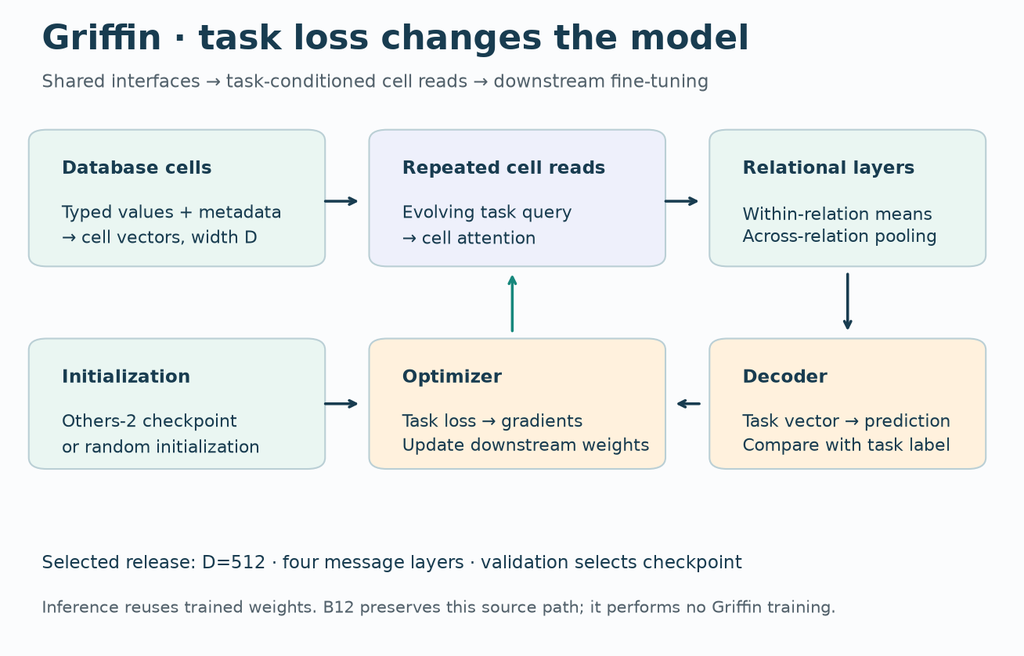

**Follow one label.** A training label contributes to the loss; the optimizer changes weights. A later query uses those changed weights. This is distinct from making that label an input value beside the query. The release's few-shot neighbor sampler is not, by itself, proof of label-based ICL.

### OpenRFM · add an example-to-example path

The paper diagnoses sparse labeled context in a relational transformer. Its dual-stage design adds a tabular ICL stage to relational representations. Its pretraining study varies synthetic diversity, real data and a prototype objective. The latter encourages useful class representations. [Primary reading: OpenRFM §§3–5](https://arxiv.org/html/2606.04320v1).

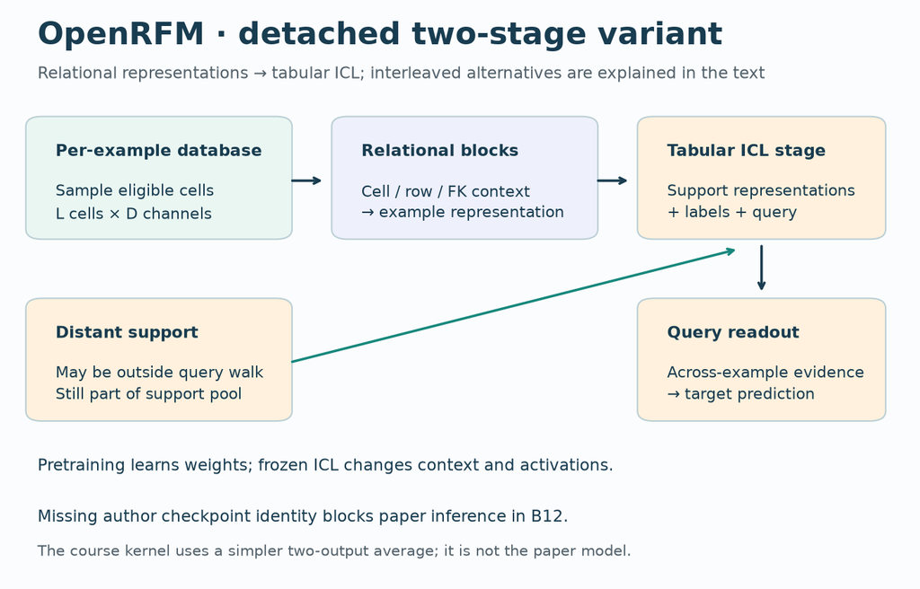

**Follow one label.** A distant support example may be absent from the query's sampled neighborhood yet available to the second-stage ICL computation. Relation-level interaction and cross-example interaction are different paths. The pictured **detached variant** pools relational-transformer representations and feeds them to a tabular ICL model. An **interleaved variant** inserts ICL layers between relational blocks; learned linear adapters match their vector widths. These are distinct integration choices. A mean of two scalar predictions is only our diagnostic, not either architecture.

### KumoRFM-2 · task information enters early

Known context targets enter table representation construction. Alternating row/column attention is followed by foreign-key and cross-sample interaction. The report describes synthetic and real pretraining; its main evaluations use frozen inference, while a separate setting fine-tunes weights. [Primary reading: KumoRFM-2 §3](https://arxiv.org/html/2604.12596v1#S3).

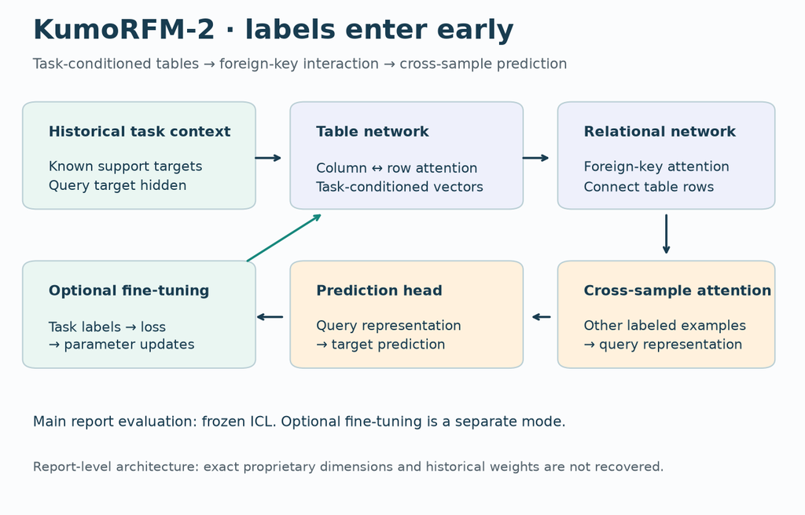

**Follow one label.** A context target can affect intermediate table representations before the final prediction. This differs from always attaching labels only to a final readout. An accessible service is a comparator, not a theoretical upper bound. The report's architecture description does not supply authenticated historical weights.

### Fill the adaptation matrix

| Selected mode | Pretraining changes weights? | New task changes weights? | Inference reads labeled context? |
| --- | --- | --- | --- |
| Griffin selected SFT release | Yes | Yes | Do not infer label ICL from sampled neighbors |
| OpenRFM frozen ICL | Yes | No | Yes |
| KumoRFM-2 main ICL evaluation | Yes | No | Yes |
| KumoRFM-2 optional fine-tuning | Yes | Yes | Context can still be used |

**SFT** means supervised fine-tuning: gradient updates using labeled examples. The rows classify selected modes, not permanent properties of a model family. The sources above support the architecture/mode descriptions; the table is a teaching synthesis.

## 3 · Worked example: a label needs a path

**Support reachability** means whether a query's sampled relational context contains an eligible labeled example. A foreign key identifies a related row. A multi-table path can bring that row into context, but the sampler may omit it.

**Worked example.** Two support labels are 0 and 1. Give them similarity logits 0 and log(3). A **logit** here is an unnormalized attention score. Exponentiating gives weights 1 and 3; dividing by their sum gives 1/4 and 3/4. Their weighted label average is **0.75**.

If the relational walk reaches neither support, our course reader returns a declared fallback of **0.5**. A second channel that can access both returns 0.75. Our diagnostic averages the channels: `(0.5 + 0.75) / 2 = 0.625`. Shuffle the labels to 1 and 0: the batch reader becomes 0.25 and the combined value becomes **0.375**. No parameter changed.

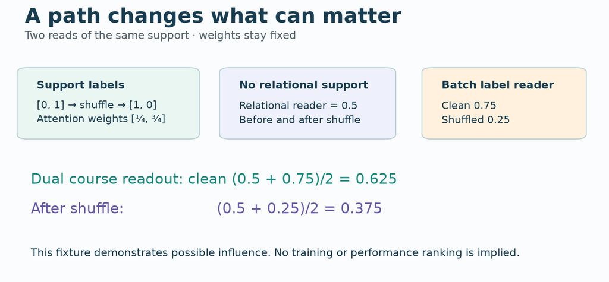

Predict first: when there is no relational label path, can shuffling support labels change the relational-only output? Can it change the dual output?

### Turn arithmetic into an operator

Let `q` be a query vector of width D, `k_i` a support vector, and `y_i` its label. Compute similarity `q · k_i / sqrt(D)`, where the dot is a sum of coordinate products. Apply a boolean permission mask before normalizing exponentials. The resulting weights sum to one over admitted supports. Multiply each admitted label by its weight and sum.

An empty permission set needs an explicit policy; ordinary softmax over only negative infinity is undefined. We choose 0.5 for this binary-label fixture. This is a stated course rule, not a recovered paper default. A missing forbidden label must be removed before multiplication: in floating-point arithmetic, `0 × NaN` remains `NaN`.

**Temporal admission.** A label is available only if its event time and arrival time are no later than the query cutoff, and its outcome window has ended. An event at day 8 with a two-day target window becomes eligible at day 10 if it has arrived. A day-8 label arriving at day 12 is unavailable at day 10. This course fixture uses inclusive boundaries and known timestamps; historical availability in real data needs its own evidence.

## 4 · Experiment: hold the examples fixed, change their access

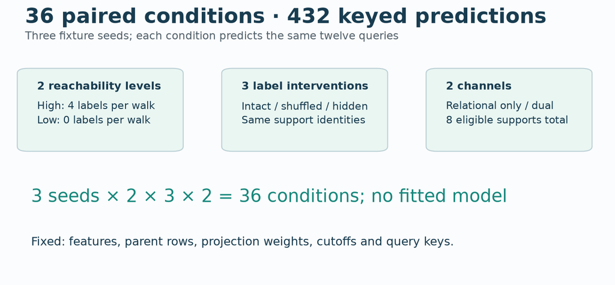

**Held fixed within each seed:** eight support rows, twelve queries, four numeric features per row, one parent feature vector per row, the complete query identities, fixed projection weights and label values before intervention. No optimizer runs. A row embedding is `(row features + 0.25 × parent features) × W`, where W is a fixed 4-by-4 matrix. The parent aggregation makes the feature path explicit.

**Varied:** three fixture seeds (0/1/2), high versus low relational reachability, intact/shuffled/hidden support labels, and relational-only versus dual channels. High reachability admits four supports per query; low admits zero. Both arms have the same eight eligible support examples available to their input protocol. The dual channel reads all eight. Thus the intervention deliberately changes effective access; it is not an equal-used-label comparison.

There are `3 × 2 × 3 × 2 = 36` conditions and `36 × 12 = 432` predictions. Shuffling permutes labels over fixed support identities, preserving their multiset. Hiding removes every label from both channels. Query labels never enter the predictor. The shuffle is one seeded draw per fixture, not a statistical test over corruption draws.

**Measured:** mean absolute prediction change from the intact condition and Brier score, the mean of `(prediction − binary target)²`. Lower Brier is better on this fixture. The target comes from the sign of the first preprojection feature coordinate. It defines an arithmetic diagnostic, not real-world accuracy or calibration evidence.

[output not shown]

SD is sample standard deviation over three fixture seeds, not a confidence interval. Change is relative to the same seed/reachability/channel with intact labels.

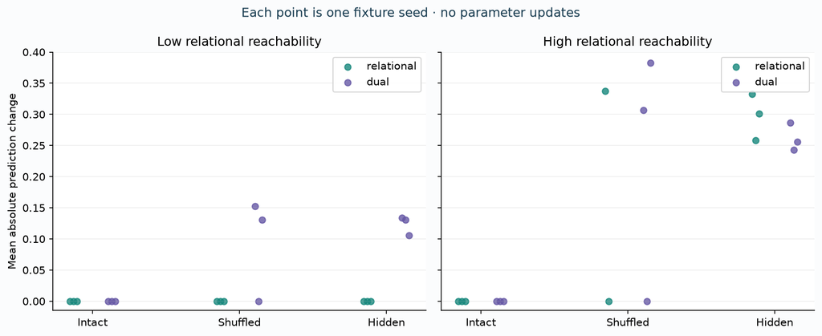

**Check the intervention itself.** The shuffle changes four label assignments in seed 0, zero in seed 1, and six in seed 2. Seed 1 permutes IDs only within equal-label groups. Its zero effect is retained; it cannot diagnose whether the model ignores labels. A future corruption study should report the realized intervention strength alongside its intended operation.

**Interpretation.** In the low-reachability relational-only arm, label corruption cannot affect a prediction because the label path is absent. The dual arm can react through its other path. Invariance with a path present has several possible causes: equal attention, identical labels, a model that ignores labels, or redundant information. Therefore one corruption result does not identify a training regime or establish useful adaptation. Look at effect sizes, the path, and the task loss together.

> **Scope check.** These are complete results for a fixed-kernel course experiment. They are not OpenRFM inference, a Griffin training run, or a Kumo implementation. A sensitive untrained kernel also demonstrates why sensitivity alone cannot prove learned feature adaptation. No architectural performance ranking follows.

## 5 · Reproduction: what is complete, what is blocked?

Full reproduction contract (in course or extracted source archive) · Frozen source ledger (in course or extracted source archive) · All keyed predictions (in course or extracted source archive) · Independent checks (in course or extracted source archive)

| Target | B12 evidence | Remaining work |
| --- | --- | --- |
| 36-condition course diagnostic | Complete; all 432 keyed predictions independently checked | Learner implementation and defense |
| Griffin v1 Table 12, Others-2 versus no-pretrain | Full inherited release model/trainer, pinned inputs and 20-fit contract preserved | Full fits stopped by inherited budget gate; no new training |
| OpenRFM v1 Table 5 | Frozen six-row source table and artifact/protocol audit | Author code/checkpoint identity and full training/evaluation protocol unresolved; NOT_RUN |
| KumoRFM-2 main evaluation | Architecture and access audit | Historical model/service identity and complete executable protocol unresolved; NOT_RUN |

Griffin retains 512/4096 labeled subsets, five subset seeds (42–46), and two arms: twenty fits. Its earlier conservative compute projection was about $63.89 before existing reservations; this is an inherited scenario estimate, not today's price quote or observed full-run cost. B12 spends **$0** on paid execution and does not silently reduce the protocol.

The repository named `T-Lab/OpenRFM` describes an independent Kumo reproduction. It is not authenticated as the author release for the OpenRFM paper. A failed repository lookup also does not prove that no release exists. These source identity checks prevent accidental substitution.

For the earlier detailed treatments, revisit L164 Griffin (in course or extracted source archive) and L191 KumoRFM-2 evaluation (in course or extracted source archive).

**Next real experiment.** Authenticate one accessible checkpoint and freeze preprocessing, support draws, query keys, label visibility, validation selection and full cost. Then test corruption on actual low/high-reachability tasks with matched support budgets. Declare any departure from a paper protocol before measuring. Until then, full-paper reproduction is `NOT_RUN`.

## TODO 1 · Temporal eligibility

Return one boolean per support: known finite event, arrival and horizon; nonnegative horizon; event and arrival no later than cutoff; completed outcome window. Reject a nonfinite cutoff or negative horizon. Equality is admitted in this fixture.

```python
def eligible_support(event, available, horizon, cutoff):
    """A label is usable once its event, arrival and outcome window are complete."""
    event,available,horizon=np.broadcast_arrays(np.asarray(event,float),np.asarray(available,float),np.asarray(horizon,float))
    if not np.isfinite(cutoff) or np.any(horizon<0):raise ValueError('Finite cutoff and nonnegative horizons required')
    return np.isfinite(event)&np.isfinite(available)&np.isfinite(horizon)&(event<=cutoff)&(available<=cutoff)&(event+horizon<=cutoff)
```

```python
def check_eligibility(fn):
    e=np.array([1.,1.,1.,np.nan,-8.]);a=np.array([2.,12.,2.,2.,-1.]);h=np.array([2.,2.,20.,2.,1.])
    assert np.array_equal(fn(e,a,h,10.),[True,False,False,False,True]), 'Check arrival and completed outcome windows; negative times can be valid'
    assert fn(np.array([8.]),np.array([10.]),np.array([2.]),10.)[0], 'Boundary is inclusive'
    try:fn(e,a,-np.ones(5),10.)
    except ValueError:pass
    else:raise AssertionError('Negative label horizons accepted')
check_eligibility(eligible_support)
print("CHECK passed: eligible_support")
```

```
CHECK passed: eligible_support
```

## TODO 2 · Masked label reader

Inputs: Q×D queries, S×D keys, S labels, Q×S boolean permissions. Return Q probabilities from scaled dot-product softmax. Empty support returns.5. Reject visible nonfinite/out-of-range labels; forbidden unknown labels must have no effect. Keep the function safe for unequal query/support counts.

```python
def label_attention(query, keys, labels, allowed):
    """Masked softmax label read; declared probability .5 when no labels admitted.

    Missing forbidden values are removed BEFORE multiplication: 0*NaN is NaN.
    """
    query=np.asarray(query,float);keys=np.asarray(keys,float);labels=np.asarray(labels,float);allowed=np.asarray(allowed)
    if query.ndim!=2 or keys.ndim!=2 or query.shape[1]!=keys.shape[1] or not query.shape[1]:raise ValueError('Q/K widths must match')
    if labels.shape!=(len(keys),) or allowed.shape!=(len(query),len(keys)) or allowed.dtype!=bool:raise ValueError('Label/mask shapes or mask type invalid')
    if not np.isfinite(query).all() or not np.isfinite(keys).all():raise ValueError('Finite features required')
    visible=allowed.any(axis=0)
    if not np.isfinite(labels[visible]).all() or np.any((labels[visible]<0)|(labels[visible]>1)):raise ValueError('Visible labels must be probabilities')
    result=np.full(len(query),.5)
    active=allowed.any(axis=1)
    if active.any():
        scores=(query[active]@keys.T)/np.sqrt(query.shape[1])
        scores=np.where(allowed[active],scores,-np.inf)
        weights=np.exp(scores-scores.max(axis=1,keepdims=True))
        weights/=weights.sum(axis=1,keepdims=True)
        result[active]=weights@np.where(visible,labels,0.)
    return result
```

```python
def check_attention(fn):
    q=np.zeros((2,1));k=np.ones((3,1));v=np.array([0.,1.,np.nan]);mask=np.array([[True,True,False],[False,False,False]])
    np.testing.assert_allclose(fn(q,k,v,mask),[.5,.5],atol=1e-12,err_msg='Equal logits average admitted labels; empty support uses declared prior .5')
    q=np.array([[1.]]);k=np.array([[0.],[np.log(3.)]]);v=np.array([0.,1.])
    np.testing.assert_allclose(fn(q,k,v,np.ones((1,2),bool)),[.75],atol=1e-12)
    np.testing.assert_allclose(fn(q,k[::-1],v[::-1],np.ones((1,2),bool)),[.75],atol=1e-12)
    try:fn(q,k,np.array([0.,np.nan]),np.ones((1,2),bool))
    except ValueError:pass
    else:raise AssertionError('Visible unknown label accepted')
check_attention(label_attention)
print("CHECK passed: label_attention")
```

```
CHECK passed: label_attention
```

## TODO 3 · Controlled label intervention

Return a new array for intact, shuffled or hidden labels. Require a full bijective integer permutation. Hidden labels become NaN and will be masked by the predictor. Do not mutate the original labels; reject unknown modes.

```python
def intervene(labels, mode, permutation):
    """Change only support labels; preserve their multiset for the shuffle arm."""
    labels=np.asarray(labels,float);permutation=np.asarray(permutation)
    if labels.ndim!=1 or permutation.dtype.kind not in 'iu' or not np.array_equal(np.sort(permutation),np.arange(len(labels))):raise ValueError('A full bijective permutation is required')
    if mode=='intact':return labels.copy()
    if mode=='shuffled':return labels[permutation].copy()
    if mode=='hidden':return np.full_like(labels,np.nan)
    raise ValueError('Unknown label intervention')
```

```python
def check_intervention(fn):
    y=np.array([0.,1.,1.,0.]);original=y.copy();perm=np.array([1,2,3,0])
    assert np.array_equal(fn(y,'intact',perm),y)
    assert np.array_equal(fn(y,'shuffled',perm),[1.,1.,0.,0.])
    assert np.isnan(fn(y,'hidden',perm)).all()
    assert np.array_equal(y,original),'Intervention mutated original labels'
    for mode,p in [('invalid',perm),('shuffled',np.array([0,0,2,3]))]:
        try:fn(y,mode,p)
        except ValueError:pass
        else:raise AssertionError('Invalid mode or permutation accepted')
check_intervention(intervene)
print("CHECK passed: intervene")
```

```
CHECK passed: intervene
```

## PROVIDED · Database fixture

Read the generator: parent features affect representations, membership edges set label reachability, and query truth is kept separate from predictor inputs. No task fitting occurs.

```python
def make_fixture(seed):
    """Eight support rows, twelve queries, each joined to one numeric parent row.

    The parent feature affects the row embedding. Separate membership edges control
    whether each query's walk reaches zero or four support task rows. All eight
    support rows are globally available at cutoff10. No label enters the features.
    """
    rng=np.random.default_rng(seed)
    x=rng.normal(size=(20,4));parent=rng.normal(size=(20,4))
    weights=np.eye(4)+rng.normal(scale=.12,size=(4,4))
    labels=((x+.25*parent)[:,0]>0).astype(float)
    high=np.zeros((12,8),bool)
    for i in range(12):high[i,[(i+j)%8 for j in range(4)]]=True
    return dict(x=x,parent=parent,weights=weights,labels=labels,high=high,low=np.zeros((12,8),bool),
                event=np.arange(8,dtype=float),available=np.arange(8,dtype=float)+2,horizon=np.ones(8),
                permutation=rng.permutation(8),keys=[(i,10) for i in range(8,20)])
```

## PROVIDED · Forward pass

Your three functions below are the live global functions called by this predictor. Replacing one changes the actual experiment, not just an isolated checker. There is deliberately no optimizer: this experiment tests inference access with fixed weights.

```python
def predict(fixture, reachability, mode, channel):
    """Visible two-stage course computation; TODO functions are called here.

    1. Parent feature aggregation + fixed projection creates row embeddings Z.
    2. Relation channel reads only reachable support labels.
    3. Dual channel also reads all eligible support labels through Z similarities.
       Equal averaging of the two outputs is a COURSE rule, not OpenRFM fusion.
    """
    if reachability not in ('high','low') or channel not in ('relational','dual'):raise ValueError('Unknown condition')
    z=(fixture['x']+.25*fixture['parent'])@fixture['weights']
    labels=intervene(fixture['labels'][:8],mode,fixture['permutation'])
    eligible=eligible_support(fixture['event'],fixture['available'],fixture['horizon'],10.)&np.isfinite(labels)
    relation_mask=fixture[reachability]&eligible[None,:]
    relational=label_attention(z[8:],z[:8],labels,relation_mask)
    if channel=='relational':return relational
    batch_mask=np.broadcast_to(eligible,(12,8))
    batch=label_attention(z[8:],z[:8],labels,batch_mask)
    return .5*(relational+batch)
```

## CHECK · Execute every approved condition

Predict the low-reachability shuffle effect before running. Retain every complete query identity and probability; no selected subset is reported.

```python
def run(output=None):
    rows=[];conditions=[]
    for seed in range(3):
        fixture=make_fixture(seed);before=hashlib.sha256(fixture['weights'].tobytes()).hexdigest()
        for reach,mode,channel in itertools.product(['high','low'],['intact','shuffled','hidden'],['relational','dual']):
            values=predict(fixture,reach,mode,channel);truth=fixture['labels'][8:]
            for key,y,p in zip(fixture['keys'],truth,values):rows.append(dict(seed=seed,reachability=reach,mode=mode,channel=channel,entity=key[0],cutoff=key[1],label=float(y),prediction=float(p)))
            clean=predict(fixture,reach,'intact',channel)
            conditions.append(dict(seed=seed,reachability=reach,mode=mode,channel=channel,brier=float(np.mean((values-truth)**2)),mean_abs_change=float(np.mean(abs(values-clean))),reachable_labels=4 if reach=='high' else 0,eligible_support_budget=8,used_support_labels=0 if mode=='hidden' else (8 if channel=='dual' else (4 if reach=='high' else 0))))
        assert hashlib.sha256(fixture['weights'].tobytes()).hexdigest()==before
    report=dict(status='COMPLETE_COURSE_DIAGNOSTIC',conditions=conditions,predictions=rows,condition_count=36,prediction_count=432,fitted_models=0,weights_unchanged=True,whole_paper='NOT_RUN',learner='PENDING_WRITTEN_DEFENSE')
    if output:
        p=Path(output);p.parent.mkdir(parents=True,exist_ok=True);payload=json.dumps(report,indent=2)+'\n'
        if p.exists() and p.read_text()!=payload:raise RuntimeError('Refusing to replace different predictions')
        p.write_text(payload)
    return report
report=run()
print(report["status"], report["condition_count"], report["prediction_count"])
```

```
COMPLETE_COURSE_DIAGNOSTIC 36 432
```

## CHECK · Independent scalar oracle and forbidden information

This recomputes attention using scalar sums/exponentials and checks all 432 predictions, labels and Brier scores. It also rejects deliberately wrong learner functions.

```python
def oracle(f,reach,mode,channel):
    # Deliberately scalar: no implementation attention, eligibility or intervention calls.
    z=[[sum((f['x'][i,k]+.25*f['parent'][i,k])*f['weights'][k,j] for k in range(4)) for j in range(4)] for i in range(20)]
    labels=list(f['labels'][:8])
    if mode=='shuffled':labels=[labels[i] for i in f['permutation']]
    def read(q,batch):
        ids=[s for s in range(8) if mode!='hidden' and (batch or f[reach][q-8,s]) and math.isfinite(f['event'][s]) and math.isfinite(f['available'][s]) and math.isfinite(f['horizon'][s]) and f['event'][s]<=10 and f['available'][s]<=10 and f['event'][s]+f['horizon'][s]<=10]
        if not ids:return .5
        scores=[sum(a*b for a,b in zip(z[q],z[s]))/2 for s in ids];mx=max(scores);ws=[math.exp(s-mx) for s in scores]
        return sum(w*labels[s] for w,s in zip(ws,ids))/sum(ws)
    return np.array([read(q,False) if channel=='relational' else .5*(read(q,False)+read(q,True)) for q in range(8,20)])

def verify(report):
    expected={(seed,r,m,c,entity,10) for seed,r,m,c,entity in itertools.product(range(3),['high','low'],['intact','shuffled','hidden'],['relational','dual'],range(8,20))}
    keys=[(r['seed'],r['reachability'],r['mode'],r['channel'],r['entity'],r['cutoff']) for r in report['predictions']]
    assert len(keys)==len(set(keys))==432 and set(keys)==expected
    assert len(report['conditions'])==36
    errors=[];interventions=0
    for seed in range(3):
        f=make_fixture(seed)
        for reach,mode,channel in itertools.product(['high','low'],['intact','shuffled','hidden'],['relational','dual']):
            rows=sorted([r for r in report['predictions'] if (r['seed'],r['reachability'],r['mode'],r['channel'])==(seed,reach,mode,channel)],key=lambda r:r['entity'])
            actual=np.array([r['prediction'] for r in rows]);target=oracle(f,reach,mode,channel);errors.append(float(max(abs(actual-target))))
            assert all(r['label']==f['labels'][r['entity']] for r in rows)
            condition=next(r for r in report['conditions'] if (r['seed'],r['reachability'],r['mode'],r['channel'])==(seed,reach,mode,channel))
            assert abs(condition['brier']-sum((r['prediction']-r['label'])**2 for r in rows)/12)<1e-12
            clean=oracle(f,reach,'intact',channel)
            assert abs(condition['mean_abs_change']-float(np.mean(abs(target-clean))))<1e-12
            changed=copy.deepcopy(f);changed['labels'][8:]=1-changed['labels'][8:]
            np.testing.assert_allclose(predict(changed,reach,mode,channel),actual,atol=1e-12);interventions+=1
        # Future / late / incomplete-window supports never affect either channel.
        for field,value in [('event',11.),('available',11.),('horizon',20.)]:
            a=copy.deepcopy(f);a[field][0]=value;b=copy.deepcopy(a);b['labels'][0]=1-b['labels'][0]
            for channel in ['relational','dual']:
                np.testing.assert_allclose(predict(a,'high','intact',channel),predict(b,'high','intact',channel),atol=1e-12);interventions+=1
        np.testing.assert_array_equal(predict(f,'low','intact','relational'),np.full(12,.5))
        np.testing.assert_array_equal(predict(f,'low','shuffled','relational'),np.full(12,.5))
        # Support permutation and independent query batches preserve attention.
        z=(f['x']+.25*f['parent'])@f['weights'];mask=np.ones((12,8),bool);perm=f['permutation']
        full=label_attention(z[8:],z[:8],f['labels'][:8],mask)
        np.testing.assert_allclose(full,label_attention(z[8:],z[:8][perm],f['labels'][:8][perm],mask[:,perm]),atol=1e-12)
        np.testing.assert_allclose(full,np.concatenate([label_attention(z[8+i:9+i],z[:8],f['labels'][:8],mask[i:i+1]) for i in range(12)]),atol=1e-12)
    assert max(errors)<1e-12
    rejected=0
    bad=[(check_eligibility,lambda e,a,h,t:np.asarray(e)<=t),(check_attention,lambda q,k,v,m:np.full(len(q),.5)),(check_intervention,lambda y,m,p:y.copy())]
    for check,fn in bad:
        try:check(fn)
        except AssertionError:rejected+=1
    assert rejected==3
    return dict(status='PASS',keyed_predictions=432,conditions=36,max_scalar_oracle_error=max(errors),forbidden_interventions=interventions,wrong_functions_rejected=rejected,support_permutation=True,query_batch_invariance=True,shuffled_label_changes=[int(np.sum(make_fixture(s)['labels'][:8]!=make_fixture(s)['labels'][:8][make_fixture(s)['permutation']])) for s in range(3)])
verification=verify(report)
print(verification)
```

```
{'status': 'PASS', 'keyed_predictions': 432, 'conditions': 36, 'max_scalar_oracle_error': 1.6653345369377348e-16, 'forbidden_interventions': 54, 'wrong_functions_rejected': 3, 'support_permutation': True, 'query_batch_invariance': True, 'shuffled_label_changes': [4, 0, 6]}
```

```python
assert report["weights_unchanged"] and report["fitted_models"]==0
(workspace/"b12-results.json").write_text(json.dumps(report,indent=2))
for c in report["conditions"]:
    print(c["seed"],c["reachability"],c["channel"],c["mode"],"Brier",round(c["brier"],4),"change",round(c["mean_abs_change"],4))
```

```
0 high relational intact Brier 0.3787 change 0.0
0 high dual intact Brier 0.3366 change 0.0
0 high relational shuffled Brier 0.5527 change 0.3372
0 high dual shuffled Brier 0.4788 change 0.3064
0 high relational hidden Brier 0.25 change 0.3328
0 high dual hidden Brier 0.25 change 0.2865
0 low relational intact Brier 0.25 change 0.0
0 low dual intact Brier 0.2589 change 0.0
0 low relational shuffled Brier 0.25 change 0.0
0 low dual shuffled Brier 0.3301 change 0.1522
0 low relational hidden Brier 0.25 change 0.0
0 low dual hidden Brier 0.25 change 0.1342
1 high relational intact Brier 0.2605 change 0.0
1 high dual intact Brier 0.1854 change 0.0
1 high relational shuffled Brier 0.2605 change 0.0
```

[output cut: 21 more lines]

## EXIT · Defend the result

Explain weights versus activations; trace labels through three architectures; distinguish eligible and used support counts. Give two explanations for corruption invariance when a path exists. Explain why a sensitive untrained kernel cannot prove feature learning. Specify an actual-checkpoint experiment with complete keys, temporal availability and validation-only selection. Ask the teaching agent for feedback. Revisit in1/7/30 days.

**Learner: PENDING_WRITTEN_DEFENSE.** Author output is not a learner score.

## NEXT STEP · Inspect the complete source packet

The archive contains pinned papers, source ledger, full Griffin source/model/trainer/operators and full reproduction contract. Original upstream license is included. No paid run is launched. Archive wrappers retain their original repository paths; the contract identifies commands to use in a full checkout. The archive digest checks transport, not historical model identity.

```python
packet=base64.b64decode('UEsDBBQAAAAIAAKyQ102Bjwb5gUAAOgMAAAYAAAAZ3JpZmZpbi9fcHJlcGFy…==')
assert hashlib.sha256(packet).hexdigest()=='65036789dc2ceaf413b9cbd078063be40ddc7777f32d796d67be4f6df3f50f69'
with zipfile.ZipFile(io.BytesIO(packet)) as z:
    assert all(not Path(n).is_absolute() and ".." not in Path(n).parts for n in z.namelist())
    z.extractall(workspace/"sources")
ledger=json.loads((workspace/"sources/source-ledger.json").read_text())
for name,digest in ledger["files"].items():
    assert hashlib.sha256((workspace/"sources"/name).read_bytes()).hexdigest()==digest
print("Source packet authenticated; full benchmarks remain NOT_RUN")
```

```
Source packet authenticated; full benchmarks remain NOT_RUN
```

## PROVIDED · Griffin full release model and trainer

These archival listings are separate from the course kernel above. Read the class/method boundaries: cell attention, relation aggregation, task decoding, training and validation selection. They are not imported into the default NumPy experiment. To reproduce the release, use the complete archived dependencies and pinned data/checkpoint contract, including the preserved budget STOP. Apache2.0 license: `sources/griffin/upstream/LICENSE` in the extracted packet.

### Archival file · hmodel.py

**PROVIDED · module setup**

```
import torch
```

**PROVIDED · module setup**

```
import torch.nn as nn
```

**PROVIDED · module setup**

```
from typing import List, Tuple, Union
```

**PROVIDED · module setup**

```
from torch import Tensor
```

**PROVIDED · module setup**

```
from torch_geometric.nn import MessagePassing
```

**PROVIDED · module setup**

```
from torch_geometric.nn.aggr import MeanAggregation, MaxAggregation
```

**PROVIDED · module setup**

```
import numpy as np
```

**PROVIDED · module setup**

```
import seaborn as sns
```

**PROVIDED · module setup**

```
import matplotlib.pyplot as plt
```

**PROVIDED · module setup**

```
from safetensors.torch import load_file
```

**PROVIDED · module setup**

```
import os
```

**PROVIDED · SelfAverageAggregator**

```
class SelfAverageAggregator(nn.Module):
    def __init__(self,
                 hiddim: int,
                 num_heads: int = 8,
                 num_layer: int = 1,
                 dim_feedforward: int = None,
                 dropout: float = 0.1):
        super().__init__()
        if dim_feedforward is None:
            dim_feedforward = hiddim
        self.linq = nn.Linear(hiddim, hiddim, bias=False)
        self.crossattention = nn.MultiheadAttention(
            hiddim, num_heads, dropout, bias=False, batch_first=True
        )

    def forward(self, column_name_emb: Tensor, x, mask=None):
        column_name_emb = column_name_emb.unsqueeze(0).expand(x.shape[0], -1, -1)
        ret = self.crossattention(
            column_name_emb,
            column_name_emb,
            x,
            key_padding_mask=mask,
            need_weights=False,
        )[0]
        return self.linq(ret)
```

**PROVIDED · SelfAttentionAggregator**

```
class SelfAttentionAggregator(nn.Module):
    def __init__(
        self,
        hiddim: int,
        num_heads=8,
        num_layer=1,
        dim_feedforward: int = None,
        dropout=0.1,
    ):
        super().__init__()
        if dim_feedforward is None:
            dim_feedforward = hiddim
        """
        self.attention_layer = nn.TransformerEncoder(
            nn.TransformerEncoderLayer(
                d_model=hiddim,
                nhead=num_heads,
                dim_feedforward=dim_feedforward,
                dropout=dropout,
                norm_first=True,
                activation="gelu",
                batch_first=True,
            ),
            num_layers=num_layer,
        )
        """
        self.linq = nn.Linear(hiddim, hiddim, bias=False)  # nn.Sequential(nn.Linear(hiddim, out_size, bias=False), nn.SiLU(inplace=True))
        self.crossattention = nn.MultiheadAttention(
            hiddim, num_heads, dropout, bias=False, batch_first=True
        )

    def forward(self, tar: Union[Tensor, None], column_name_emb: Tensor, x, mask=None):
        # tar: (batch_size, q_len, hiddim)
        # x: (batch_size, seq_len, hiddim)
        # column_name_emb: (seq_len, hiddim)
        # return: (batch_size, q_len, hiddim)
        column_name_emb = column_name_emb.unsqueeze(0)
        # column_name_emb = self.attention_layer(column_name_emb)# transformer encoder has res + column_name_emb
        q = tar  # self.linq(tar)
        ret = self.crossattention(
            q,
            column_name_emb.expand(x.shape[0], -1, -1),
            x,
            key_padding_mask=mask,
            need_weights=False,
        )[0]
        return ret * self.linq(tar)
```

**PROVIDED · checktaskfeat**

```
def checktaskfeat(taskfeat: List[Tensor], node: List[Tuple[Tensor, Tensor]]):
    for i in range(len(taskfeat)):
        if taskfeat[i] is None:
            taskfeat[i] = node[i][0].mean(dim=0)
        if taskfeat[i].ndim == 1:
            taskfeat[i] = taskfeat[i].unsqueeze(0).expand(node[i][1].shape[0], -1)
        assert taskfeat[i].ndim == 2
    return taskfeat
```

**PROVIDED · _attention_merge_feat_self_attention**

```
def _attention_merge_feat_self_attention(
    attention_model: SelfAttentionAggregator,
    feat: Tensor,  # [#node, #feat, hiddim]
    colfeat: Tensor,  # [#feat, hiddim]
    mask: Union[Tensor, None],  # [#node, #feat]
) -> Tensor:
    return torch.mean(attention_model(colfeat, feat, mask), dim=1)
```

**PROVIDED · _attention_merge_feat_with_relation**

```
def _attention_merge_feat_with_relation(
    attention_model: SelfAttentionAggregator,
    feat: Tensor,  # [#node, #feat, hiddim]
    colfeat: Tensor,  # [#feat, hiddim]
    taskfeat: Union[Tensor, None],  # [#node, hiddim]
    mask: Union[Tensor, None],  # [#node, #feat]
) -> Tensor:
    return attention_model(taskfeat.unsqueeze(1), colfeat, feat, mask).squeeze(1)
```

**PROVIDED · module setup**

```
'''
class RMPNN(MessagePassing):

    def __init__(self, hiddim) -> None:
        super().__init__(aggr="mean", flow="target_to_source")
        self.rellin = nn.Sequential(
            nn.Linear(hiddim, hiddim)
        )  # , nn.SiLU(inplace=True))

    def reset_parameters(self) -> None:
        return self.rellin[0].reset_parameters()

    def forward(
        self,
        x: Tensor,
        edge_index: Tensor,
        edge_attr_type: Tensor,
        edge_attr: Tensor,
    ) -> Tensor:
        if edge_index is None or edge_index.shape[1] == 0:
            return 0 * self.rellin(x[0])
        edge_attr = self.rellin(edge_attr)[edge_attr_type]
        out = self.propagate(
            edge_index, edge_attr=edge_attr, x=x, size=(x.shape[0], x.shape[0])
        )
        return out

    def message(self, edge_attr, x_j: Tensor) -> Tensor:
        return edge_attr * x_j
'''
```

**PROVIDED · RMPNN**

```
class RMPNN(nn.Module):

    def __init__(self, hiddim) -> None:
        super().__init__()
        self.rellin = nn.Sequential(
            nn.Linear(hiddim, hiddim)
        )  # , nn.SiLU(inplace=True))
        self.aggr1 = MeanAggregation()
        self.aggr2 = MaxAggregation()

    def reset_parameters(self) -> None:
        return self.rellin[0].reset_parameters()

    def forward(
        self,
        x: Tensor,
        edge_index: Tensor,
        edge_attr_type: Tensor,
        edge_attr: Tensor
    ) -> Tensor:
        if edge_index is None or edge_index.shape[1] == 0:
            return 0 * self.rellin(x[0])
        edge_attr = self.rellin(edge_attr) # [edge_attr_type]

        center, inv = torch.unique(torch.stack((edge_index[0], edge_attr_type), dim=0), dim=1, return_inverse=True)
        out1 = self.aggr1(x[edge_index[1]], inv, dim_size=center.shape[1])
        out2 = self.aggr2(out1*edge_attr[center[1]], center[0], dim_size=x.shape[0])
        return out2
```

**PROVIDED · GriffinMod**

```
class GriffinMod(nn.Module):
    def __init__(
        self,
        hiddim: int = 256,
        num_tf: int = 1,
        num_mp: int = 2,
        use_rev: bool = True,
        use_gate: bool = True,
    ):
        super().__init__()
        self.nodefeataggr = nn.ModuleList(
            # The 0-layer is a simple average aggregator
            [
                SelfAverageAggregator(hiddim, num_layer=num_tf)
            ]
            # The rest are self-attention aggregators
            + [SelfAttentionAggregator(hiddim, num_layer=num_tf) for _ in range(num_mp - 1)]
        )
        self.mpnn = nn.ModuleList([RMPNN(hiddim) for _ in range(num_mp)])
        self.lintask = nn.ModuleList(
            [nn.Linear(hiddim, hiddim, bias=False) for _ in range(num_mp - 1)]
        )
        self.mlp = nn.ModuleList(
            [
                nn.Sequential(
                    nn.Linear(hiddim, hiddim, bias=False), nn.SiLU(inplace=True)
                )
                for _ in range(num_mp)
            ]
        )
        self.mlp2 = nn.ModuleList(
            [
                nn.Sequential(
                    nn.Linear(hiddim, hiddim, bias=False), nn.SiLU(inplace=True), nn.Linear(hiddim, hiddim, bias=False),
                )
                for _ in range(num_mp)
            ]
        )
        self.num_mp = num_mp
        self.ln = nn.LayerNorm(hiddim, elementwise_affine=False)
        self.use_rev = use_rev
        self.use_gate = use_gate

        self.gatelin = nn.ModuleList(
            [
                nn.Sequential(
                    nn.Linear(hiddim, int(hiddim**0.5)),
                    nn.SiLU(inplace=True),
                    nn.Linear(int(hiddim**0.5), 1, bias=False),
                    # nn.Tanh(),
                )
                for _ in range(num_mp)
            ]
        ) if use_gate else None
        self.revmpnn = nn.ModuleList([RMPNN(hiddim) for _ in range(num_mp)]) if use_rev else None
        self.revgatelin = nn.ModuleList(
            [
                nn.Sequential(
                    nn.Linear(hiddim, int(hiddim**0.5)),
                    nn.SiLU(inplace=True),
                    nn.Linear(int(hiddim**0.5), 1, bias=False),
                    # nn.Tanh(),
                )
                for _ in range(num_mp)
            ]
        ) if use_gate and use_rev else None
        with torch.no_grad():
            for _ in range(num_mp):
                if use_gate:
                    self.gatelin[_][2].weight.fill_(0.0)
                    if use_rev:
                        self.revgatelin[_][2].weight.fill_(0.0)

    def reset_parameters(self):
        for i in range(len(self.mpnn)):
            self.mpnn[i].reset_parameters()
            if self.gatelin is not None:
                self.gatelin[i][0].reset_parameters()

    def forward_with_each_layer_output(
        self,
        node: List[Tuple[Tensor, Tensor]],
        mask: List[Union[Tensor, None]],
        taskfeat: List[Union[Tensor, None]],
        edge_index: Tensor,
        edge_attr_type: Tensor,
        edge_attr: Tensor,
    ) -> Tensor:
        assert len(node) == len(mask)
        assert len(node) == len(taskfeat)
        num_node: int = len(node)
        taskfeat = checktaskfeat(taskfeat, node)
        nodeptr = [0] + [_.shape[0] for _ in taskfeat]
        nodeptr = np.cumsum(nodeptr)

        return_x = []

        for i in range(self.num_mp):
            if i == 0:
                x = torch.concat(
                    [
                        _attention_merge_feat_self_attention(
                            self.nodefeataggr[i],
                            feat,
                            colfeat,
                            mask[j],
                        )
                        for j, (colfeat, feat) in enumerate(node)
                    ],
                    dim=0,
                )
            else:
                x = x + torch.concat(
                    [
                        _attention_merge_feat_with_relation(
                            self.nodefeataggr[i],
                            feat,
                            colfeat,
                            self.ln(taskfeat[j]),
                            mask[j],
                        )
                        for j, (colfeat, feat) in enumerate(node)
                    ],
                    dim=0,
                )
            lnx = self.ln(x)
            mlpx = self.mlp[i](lnx)
            x = (
                x
                + self.mlp2[i](lnx)
                + (
                    (self.gatelin[i](lnx) if self.use_gate else 1)
                    * self.mpnn[i](mlpx, edge_index, edge_attr_type, edge_attr)
                )
                + (
                    (
                        (self.revgatelin[i](lnx) if self.use_gate else 1)
                        * self.revmpnn[i](mlpx, None if edge_index is None else edge_index[[1, 0]], edge_attr_type, edge_attr)
                    )
                    if self.use_rev
                    else 0
                )
            )
            return_x.append(x.detach().cpu())

            if i < self.num_mp - 1:
                ntaskfeat = self.lintask[i](self.ln(x))
                for j in range(num_node):
                    taskfeat[j] = ntaskfeat[nodeptr[j] : nodeptr[j + 1]] + taskfeat[j]
        return return_x

    def forward(
        self,
        node: List[Tuple[Tensor, Tensor]],
        mask: List[Union[Tensor, None]],
        taskfeat: List[Union[Tensor, None]],
        edge_index: Tensor,
        edge_attr_type: Tensor,
        edge_attr: Tensor,
    ) -> Tensor:
        assert len(node) == len(mask)
        assert len(node) == len(taskfeat)
        num_node: int = len(node)
        taskfeat = checktaskfeat(taskfeat, node)
        nodeptr = [0] + [_.shape[0] for _ in taskfeat]
        nodeptr = np.cumsum(nodeptr)

        for i in range(self.num_mp):
            if i == 0:
                x = torch.concat(
                    [
                        _attention_merge_feat_self_attention(
                            self.nodefeataggr[i],
                            feat,
                            colfeat,
                            mask[j],
                        )
                        for j, (colfeat, feat) in enumerate(node)
                    ],
                    dim=0,
                )
            else:
                x = x + torch.concat(
                    [
                        _attention_merge_feat_with_relation(
                            self.nodefeataggr[i],
                            feat,
                            colfeat,
                            self.ln(taskfeat[j]),
                            mask[j],
                        )
                        for j, (colfeat, feat) in enumerate(node)
                    ],
                    dim=0,
                )
            lnx = self.ln(x)
            mlpx = self.mlp[i](lnx)
            x = (
                x
                + self.mlp2[i](lnx)
                + (
                    (self.gatelin[i](lnx) if self.use_gate else 1)
                    * self.mpnn[i](mlpx, edge_index, edge_attr_type, edge_attr)
                )
                + (
                    (
                        (self.revgatelin[i](lnx) if self.use_gate else 1)
                        * self.revmpnn[i](mlpx, None if edge_index is None else edge_index[[1, 0]], edge_attr_type, edge_attr)
                    )
                    if self.use_rev
                    else 0
                )
            )

            if i < self.num_mp - 1:
                ntaskfeat = self.lintask[i](self.ln(x))
                for j in range(num_node):
                    taskfeat[j] = ntaskfeat[nodeptr[j] : nodeptr[j + 1]] + taskfeat[j]
        return self.ln(x)
```

**PROVIDED · visualize_parameter_heatmaps**

```
def visualize_parameter_heatmaps(model, model_name, figsize=(15, 25)):
    """
    Create heatmap visualizations for GriffinMod parameters with dynamic subplot layout
    """
    # Count total number of plots needed
    num_plots = (
        len(model.nodefeataggr) +  # Attention weights
        len(model.lintask) +      # Linear task weights
        len(model.mpnn) +          # MPNN weights
        len(model.revmpnn) +      # Reverse MPNN weights
        len(model.mlp) +           # MLP weights
        len(model.mlp2) * 2 +          # MLP2 weights, with two layers
        (len(model.gatelin) if model.use_gate else 0) * 2 +   # Gate weights if enabled
        (len(model.revgatelin) if model.use_gate and model.use_rev else 0) * 2
    )

    # Calculate optimal grid layout
    num_cols = 4  # You can adjust this
    num_rows = (num_plots + num_cols - 1) // num_cols  # Ceiling division

    # Adjust figure size based on number of rows
    figsize = (7.5 * num_cols, 5 * num_rows)
    fig = plt.figure(figsize=figsize)

    def plot_weight_heatmap(weight, title, subplot_idx):
        plt.subplot(num_rows, num_cols, subplot_idx)
        # Convert to numpy and handle 2+ dimensional tensors
        if weight.ndim > 2:
            weight = weight.reshape(weight.shape[0], -1)
        weight_np = weight.detach().cpu().numpy()

        # Create heatmap with seaborn
        sns.heatmap(
            weight_np,
            cmap='RdBu_r',  # Red-Blue diverging colormap
            center=0,       # Center the colormap at 0
            vmin=-np.abs(weight_np).max(),  # Symmetric scale
            vmax=np.abs(weight_np).max(),
            xticklabels=False,  # Hide x-axis ticks for cleaner visualization
            cbar_kws={'label': 'Weight Value'}
        )
        plt.title(f'{title}\nShape: {tuple(weight.shape)}')
        plt.ylabel('Output Features')

    current_plot = 1

    # 1. Attention Weights
    for i, aggr in enumerate(model.nodefeataggr):
        weights = aggr.crossattention.in_proj_weight
        plot_weight_heatmap(weights, f'Layer {i} Attention Weights', current_plot)
        current_plot += 1

    # 2. Linear task weights
    for i, lintask in enumerate(model.lintask):
        weights = lintask.weight
        plot_weight_heatmap(weights, f'Layer {i} Linear Task Weights', current_plot)
        current_plot += 1

    # 3. MPNN Weights
    for i, mp in enumerate(model.mpnn):
        weights = mp.rellin[0].weight
        plot_weight_heatmap(weights, f'Layer {i} MPNN Weights', current_plot)
        current_plot += 1

    # 4. Reverse MPNN Weights
    for i, revmp in enumerate(model.revmpnn):
        weights = revmp.rellin[0].weight
        plot_weight_heatmap(weights, f'Layer {i} Reverse MPNN Weights', current_plot)
        current_plot += 1

    # 5. MLP Weights
    for i, mlp in enumerate(model.mlp):
        weights = mlp[0].weight
        plot_weight_heatmap(weights, f'Layer {i} MLP Weights', current_plot)
        current_plot += 1


    # 6. MLP2 Weights
    for i, mlp2 in enumerate(model.mlp2):
        weights = mlp2[0].weight
        plot_weight_heatmap(weights, f'Layer {i} MLP2-0 Weights', current_plot)
        current_plot += 1
        weights = mlp2[2].weight
        plot_weight_heatmap(weights, f'Layer {i} MLP2-2 Weights', current_plot)
        current_plot += 1

    # 7. Gate Weights
    if model.use_gate:
        for i, gate in enumerate(model.gatelin):
            weights = gate[0].weight
            plot_weight_heatmap(weights, f'Layer {i} Gate-0 Weights', current_plot)
            current_plot += 1
            weights = gate[2].weight
            plot_weight_heatmap(weights, f'Layer {i} Gate-2 Weights', current_plot)
            current_plot += 1

    # 8. Reverse Gate Weights
    if model.use_gate and model.use_rev:
        for i, gate in enumerate(model.revgatelin):
            weights = gate[0].weight
            plot_weight_heatmap(weights, f'Layer {i} Reverse Gate-0 Weights', current_plot)
            current_plot += 1
            weights = gate[2].weight
            plot_weight_heatmap(weights, f'Layer {i} Reverse Gate-2 Weights', current_plot)
            current_plot += 1

    plt.tight_layout()
    plt.show()
    plt.savefig(f"{model_name}.png")
```

**PROVIDED · module setup**

```
if __name__ == "__main__":
    def str2bool(v):
        if isinstance(v, bool):
            return v
        if v.lower() in ("yes", "true", "t", "y", "1"):
            return True
        elif v.lower() in ("no", "false", "f", "n", "0"):
            return False
        else:
            raise argparse.ArgumentTypeError("Boolean value expected.")
    import argparse
    parser = argparse.ArgumentParser()
    parser.add_argument("--loadpath", type=str, default="checkpoints/single-pretrain-v3-completion-search/log-25/best_checkpoint/model.safetensors")
    parser.add_argument("--model_name", type=str, default="griffin")
    parser.add_argument("--folder", type=str2bool, default=False)
    args = parser.parse_args()
    model = GriffinMod(hiddim=512, num_mp=4, use_rev=True, use_gate=True)
    model_name = args.model_name

    # Load checkpoint directly with torch.load
    if args.folder:
        for file in os.listdir(args.loadpath):
            # file is still a folder, including the model.safetensors
            checkpoint = load_file(os.path.join(args.loadpath, file, "model.safetensors"))
            model.load_state_dict(checkpoint)
            visualize_parameter_heatmaps(model, f"{model_name}_{file}")
    else:
        checkpoint = load_file(os.path.join(args.loadpath, "model.safetensors"))
        model.load_state_dict(checkpoint)
        visualize_parameter_heatmaps(model, args.model_name)
```

### Archival file · hmaintask_downsample_absolute_eval_sample.py

**PROVIDED · module setup**

```
import torch
```

**PROVIDED · module setup**

```
import torch.nn.functional as F
```

**PROVIDED · module setup**

```
from hdataset import Graph, Task
```

**PROVIDED · module setup**

```
from hloaderwrapper import LoaderWrapperTask
```

**PROVIDED · module setup**

```
from hmodel import GriffinMod
```

**PROVIDED · module setup**

```
from torch.utils.data import DataLoader
```

**PROVIDED · module setup**

```
from accelerate import Accelerator
```

**PROVIDED · module setup**

```
from accelerate.utils import ProjectConfiguration
```

**PROVIDED · module setup**

```
from hFloatEmb import SimpleRepeater, getfloatdec
```

**PROVIDED · module setup**

```
import numpy as np
```

**PROVIDED · module setup**

```
import accelerate
```

**PROVIDED · module setup**

```
import argparse
```

**PROVIDED · module setup**

```
import os.path as osp
```

**PROVIDED · module setup**

```
from typing import Union
```

**PROVIDED · module setup**

```
from metric import compute_metric
```

**PROVIDED · module setup**

```
import os
```

**PROVIDED · module setup**

```
import shutil
```

**PROVIDED · module setup**

```
import yaml
```

**PROVIDED · eval_task**

```
def eval_task(model, dec, dataset, args, accelerator, metric, with_sample=False):
    model.eval()
    if with_sample and args.eval_sample_ratio < 1:
        dataset.rebuild_indice_downsample(accelerator, args.eval_sample_ratio, args.eval_sample_seed)
    else:
        dataset.rebuild_indice(accelerator)
    batchsize: int = dataset.batch_size
    loader = DataLoader(
        dataset,
        shuffle=False,
        batch_size=1,
        collate_fn=lambda xlist: xlist[0],
        num_workers=8,
        persistent_workers=False,
    )
    loader = accelerator.prepare(loader)
    outputs = []
    labels = []
    with torch.no_grad():
        for data in loader:
            output, label = compute_output(model, dec, data)
            if output.shape[0] < batchsize:
                assert output.ndim == 2
                assert label.ndim == 1
                padnum = batchsize-output.shape[0]
                if torch.is_floating_point(label):
                    label = torch.concat((label, torch.empty_like(label[[0]].expand(padnum)).fill_(torch.nan)), dim=0)
                else:
                    label = torch.concat((label, torch.empty_like(label[[0]].expand(padnum)).fill_(-1)), dim=0)
                output = torch.concat((output, torch.empty_like(output[[0]].expand(padnum, -1)).fill_(torch.nan)), dim=0)
            output, label = output.unsqueeze(0), label.unsqueeze(0)
            output, label = accelerator.gather_for_metrics((output, label))
            output, label = output.flatten(0, 1), label.flatten(0, 1)
            if accelerator.is_main_process:
                if torch.is_floating_point(label):
                    mask = torch.isnan(label).logical_not_()
                else:
                    mask = label >= 0
                output, label = output[mask], label[mask]
                outputs.append(output.cpu())
                labels.append(label.cpu())
    #if metric.requires_gather:
    #    metric.outputs, metric.labels = accelerator.gather_for_metrics((metric.outputs, metric.labels))
    if accelerator.is_main_process:
        labels = torch.concat(labels, dim=0)
        outputs = torch.concat(outputs, dim=0)
        return compute_metric(outputs, labels, metric)
    else:
        return None
```

**PROVIDED · construct_dataset**

```
def construct_dataset(graph, task, tasknames, split, args, floatembmodel):
    return LoaderWrapperTask(
        graph,
        batch_size=args.batchsize,
        subgraphargs={
            "floatemb": floatembmodel,
            "fanout": args.fanout,
            "hop": args.hop,
        },
        shuffle=True if split == "train" else False,
        task=task,
        tasknames=tasknames,
        split=split,
        fewshotfanout=args.fewshotfanout,
    )
```

**PROVIDED · compute_output**

```
def compute_output(model, dec, data):
    label, y, mapping = data[-3:]
    data = data[:-3]
    if y is None:
        output = dec(model(*data)[mapping])
    else:
        output = model(*data)[mapping] @ y.T
    return output, label
```

**PROVIDED · compute_loss**

```
def compute_loss(model, dec, data):
    label, y, mapping = data[-3:]
    data = data[:-3]
    if y is None:
        output = dec(model(*data)[mapping])
        loss = F.mse_loss(output.flatten(), label.flatten())
    else:
        output = model(*data)[mapping] @ y.T
        loss = F.cross_entropy(output, label)
    return loss
```

**PROVIDED · main**

```
def main(args):
    tbconfig = ProjectConfiguration(project_dir=args.logdir, logging_dir=args.logdir)
    accelerator = Accelerator(log_with="tensorboard", project_config=tbconfig)
    accelerator.init_trackers(args.logname)
    tbtracker = accelerator.get_tracker("tensorboard")

    model = GriffinMod(hiddim=args.hiddim, num_mp=args.num_mp, use_rev=args.use_rev, use_gate=args.use_gate)
    if args.loadpath is not None:
        accelerate.load_checkpoint_in_model(model, args.loadpath)
    # model.reset_parameters()
    dec = getfloatdec(args.hiddim)

    optimizer = torch.optim.AdamW(model.parameters(), lr=args.lr, weight_decay=args.wd)
    graph = Graph(args.dataset)
    task = Task(args.dataset)

    tasknames = args.tasks
    if len(tasknames) == 1:
        if tasknames[0] == "ALLTASK":
            tasknames = [taskname for taskname in task.metatask]
        elif tasknames[0] == "RETTASK":
            tasknames = [
                taskname
                for taskname in task.metatask
                if task.metatask[taskname]["task_type"] == "retrieval"
            ]
        elif tasknames[0] == "REGTASK":
            tasknames = [
                taskname
                for taskname in task.metatask
                if task.metatask[taskname]["task_type"] == "regression"
            ]
        elif tasknames[0].startswith("EXCEPT__"):
            expect_taskname = tasknames[0][len("EXCEPT__"):]
            tasknames = [taskname for taskname in task.metatask if taskname != expect_taskname]
        elif tasknames[0] in ["commerce-1", "commerce-2", "others-1", "others-2"]:
            with open("task_names.yaml", "r") as f:
                tasks_dict = yaml.load(f, Loader=yaml.FullLoader)
            tasknames = tasks_dict[tasknames[0]]
    if accelerator.is_main_process:
        print(tasknames)

    floatembmodel = SimpleRepeater(args.hiddim)

    dataset = construct_dataset(graph, task, tasknames, "train", args, floatembmodel)
    valid_dataset_dict = {
        taskname: construct_dataset(graph, task, [taskname], "valid", args, floatembmodel)
        for taskname in tasknames
    }
    test_dataset_dict = {
        taskname: construct_dataset(graph, task, [taskname], "test", args, floatembmodel)
        for taskname in tasknames
    }
    metric_dict = {
        taskname: task.metatask[taskname]["metric"] for taskname in tasknames
    }
    best_valid_metric = -torch.inf
    best_checkpoint_path = None
    best_epoch = 0

    model, dec, optimizer = accelerator.prepare(model, dec, optimizer)

    if args.mode == "test":
        test_metric = {}
        for taskname in tasknames:
            if accelerator.is_main_process:
                print(f"test {taskname}...")
            eval_metric = eval_task(
                model,
                dec,
                test_dataset_dict[taskname],
                args,
                accelerator,
                metric_dict[taskname],
            )
            test_metric[taskname] = eval_metric
            if accelerator.is_main_process:
                print(f"test_metric/{taskname}: {test_metric[taskname]}", flush=True)
        accelerator.end_training()
        return

    model.train()
    step = 0
    for epoch in range(args.maxepoch):
        if accelerator.is_main_process:
            print(f"Epoch {epoch} starts")
        dataset.rebuild_indice_downsample_absolute(accelerator, args.downsample_num, args.downsample_seed)
        loader = DataLoader(
            dataset,
            shuffle=True,
            batch_size=1,
            collate_fn=lambda xlist: xlist[0],
            num_workers=16,
            prefetch_factor=4,
            persistent_workers=False,
            pin_memory=True
        )
        loader = accelerator.prepare(loader)
        for data in loader:
            step += 1
            optimizer.zero_grad()
            loss = compute_loss(model, dec, data)
            accelerator.backward(loss)
            optimizer.step()
            if step % 100 == 0:
                tbtracker.log({"training_loss": loss}, step=step)
        accelerator.wait_for_everyone()
        checkpoint_path = osp.join(args.savepath, f"checkpoint-{epoch}-{step}") if args.savepath is not None else None
        if args.savepath is not None:
            if accelerator.is_main_process:
                accelerator.save_model(model, checkpoint_path)
        if (epoch + 1) % args.eval_per_epoch == 0:
            # Switch to eval mode.
            eval_metric = {}
            for taskname in tasknames:
                if accelerator.is_main_process:
                    print(f"Validating {taskname}...")
                eval_metric[taskname] = eval_task(
                    model,
                    dec,
                    valid_dataset_dict[taskname],
                    args,
                    accelerator,
                    metric_dict[taskname],
                    with_sample=True,
                )
                if accelerator.is_main_process:
                    tbtracker.log({f"valid_metric/{taskname}/{metric_dict[taskname]}": eval_metric[taskname]}, step=step)
                    print(f"valid_metric/{taskname}/{metric_dict[taskname]}: {eval_metric[taskname]}", flush=True)
            if accelerator.is_main_process:
                avg_valid_metric = sum(eval_metric.values()) / len(eval_metric)
                print(f"Average valid metric: {avg_valid_metric}", flush=True)
            # spread the metric to all processes
            avg_valid_metric = accelerator.gather(torch.tensor([avg_valid_metric if accelerator.is_main_process else 0.0]).to(model.device)).mean().item()
            if avg_valid_metric > best_valid_metric:
                best_valid_metric = avg_valid_metric
                best_checkpoint_path = checkpoint_path
                best_epoch = epoch
                eval_metric = {}
                for taskname in tasknames:
                    if accelerator.is_main_process:
                        print(f"test {taskname}...")
                    eval_metric[taskname] = eval_task(
                        model,
                        dec,
                        test_dataset_dict[taskname],
                        args,
                        accelerator,
                        metric_dict[taskname],
                        with_sample=True,
                    )
                    if accelerator.is_main_process:
                        tbtracker.log({f"test_metric/{taskname}/{metric_dict[taskname]}": eval_metric[taskname]}, step=step)
                        print(f"test_metric/{taskname}/{metric_dict[taskname]}: {eval_metric[taskname]}", flush=True)
                if accelerator.is_main_process:
                    avg_test_metric = sum(eval_metric.values()) / len(eval_metric)
                    print(f"Average test metric: {avg_test_metric}", flush=True)
            if args.patience > 0 and epoch - best_epoch > args.patience:
                print(f"Early stopping at epoch {epoch}")
                break
            model.train()

    test_metric = {}
    if best_checkpoint_path is not None:
        if accelerator.is_main_process:
            print(f"Loading best checkpoint from {best_checkpoint_path}")
        unwrap_model = accelerator.unwrap_model(model)
        accelerate.load_checkpoint_in_model(unwrap_model, best_checkpoint_path)
        model = accelerator.prepare(unwrap_model)
        # resave the best checkpoint
        if accelerator.is_main_process:
            print(f"Saving best checkpoint at {osp.join(args.savepath, 'best_checkpoint')}")
            accelerator.save_model(model, osp.join(args.savepath, 'best_checkpoint'))

    for taskname in tasknames:
        if accelerator.is_main_process:
            print(f"Testing {taskname}...")
        eval_metric = eval_task(
            model,
            dec,
            test_dataset_dict[taskname],
            args,
            accelerator,
            metric_dict[taskname],
        )
        if accelerator.is_main_process:
            tbtracker.log({f"test_metric/{taskname}": eval_metric}, step=step)
            print(f"test_metric/{taskname}: {eval_metric}")
            test_metric[taskname] = eval_metric

    if accelerator.is_main_process:
        avg_metric = sum(test_metric.values()) / len(test_metric)
        print(f"Average test metric: {avg_metric}")

    accelerator.end_training()
    if args.savepath is not None and accelerator.is_main_process:
        # delete other checkpoints
        for file in os.listdir(args.savepath):
            # only keep the directory "best_checkpoint"
            if file.startswith('checkpoint-') and file != 'best_checkpoint':
                shutil.rmtree(osp.join(args.savepath, file))
```

**PROVIDED · module setup**

```
if __name__ == "__main__":
    def str2bool(v):
        if isinstance(v, bool):
            return v
        if v.lower() in ("yes", "true", "t", "y", "1"):
            return True
        elif v.lower() in ("no", "false", "f", "n", "0"):
            return False
        else:
            raise argparse.ArgumentTypeError("Boolean value expected.")

    parser = argparse.ArgumentParser()
    parser.add_argument("--mode", type=str, default="train", help="train or test")
    parser.add_argument("dataset", type=str)
    parser.add_argument("logdir", type=str)
    parser.add_argument("logname", type=str)
    parser.add_argument(
        "--tasks",
        type=str,
        nargs="+",
        default=["ALLTASK"],
        help="ALLTASK for all tasks. RETTASK for all retrieval task. REGTASK for all regression task. Otherwise input a list of task name",
    )
    parser.add_argument("--savepath", type=str, default=None)
    parser.add_argument("--loadpath", type=str, default=None)
    parser.add_argument("--seed", type=int, default=42)

    parser.add_argument("--batchsize", type=int, default=512)
    parser.add_argument("--eval_batchsize", type=int)
    parser.add_argument("--lr", type=float, default=3e-4)
    parser.add_argument("--wd", type=float, default=4e-4)
    parser.add_argument("--maxepoch", type=int, default=10)
    parser.add_argument("--patience", type=int, default=-1)
    parser.add_argument("--eval_per_epoch", type=int, default=3)
    parser.add_argument("--downsample_num", type=int, default=256)
    parser.add_argument("--downsample_seed", type=int, default=42)
    parser.add_argument("--eval_sample_ratio", type=float, default=1)
    parser.add_argument("--eval_sample_seed", type=int, default=42)

    parser.add_argument("--num_mp", type=int, default=4)
    parser.add_argument("--hiddim", type=int, default=256)
    parser.add_argument("--fanout", type=int, default=10)
    parser.add_argument("--fewshotfanout", type=int, default=3)
    parser.add_argument("--hop", type=int, default=2)
    parser.add_argument("--use_rev", type=str2bool, default=True)
    parser.add_argument("--use_gate", type=str2bool, default=True)

    args = parser.parse_args()
    args.eval_batchsize = args.batchsize if args.eval_batchsize is None else args.eval_batchsize
    # seed everything
    torch.manual_seed(args.seed)
    torch.cuda.manual_seed(args.seed)
    np.random.seed(args.seed)
    main(args)
```

## Full-run gate

Griffin Table12:20 fits, unchanged 512/4096 subsets and seeds 42–46, INCOMPLETE_BUDGET_GATE. OpenRFM Table5: INCOMPLETE_SOURCE_PROTOCOL. KumoRFM-2: INCOMPLETE_MODEL_IDENTITY. No guessed substitutes or unpinned service calls. Whole-paper NOT_RUN; live Colab NOT_CHECKED. See the extracted `b12-reproduction.md` for the full named protocols and source gaps.

```python
RUN_FULL_REPRO=False
if RUN_FULL_REPRO:
    raise RuntimeError("BLOCKED: USD0 scope and unresolved budget/source/model gates; read b12-reproduction.md")
```